# Apply OE

[output not shown]

```
WARNING:2026-07-28,02:15:14 || image.py:_normalize_image_array() | Clipping input data to the valid range for imshow with RGB data ([0..1] for floats or [0..255] for integers). Got range [0.1097916..1.0983623].
```

```
WARNING:2026-07-28,02:15:14 || image.py:_normalize_image_array() | Clipping input data to the valid range for imshow with RGB data ([0..1] for floats or [0..255] for integers). Got range [0.121814415..1.5453982].
```

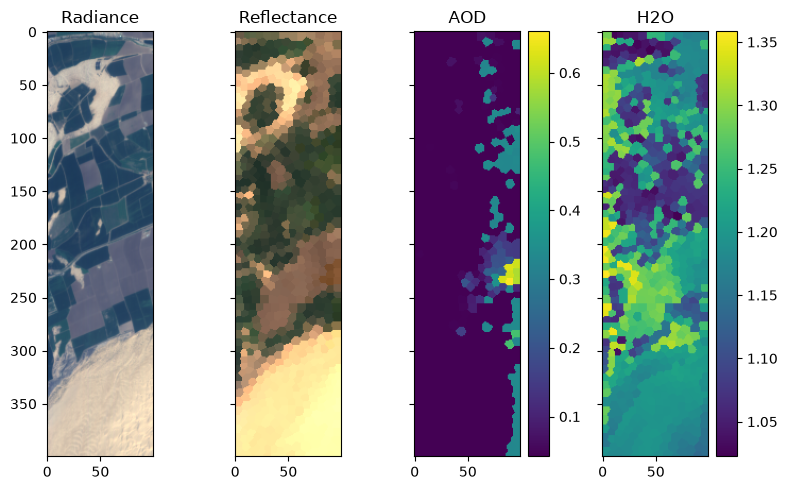

Finally, we can examine the final results at the end of the anlaytical line algorithm:

```python
rfl_path = env.path("examples", "image_cube", "medium", "output", "ang20170323t202244_rfl")
atm_path = env.path("examples", "image_cube", "medium", "output", "ang20170323t202244_atm_interp")

rfl  = envi.open(envi_header(str(rfl_path)))
atm  = envi.open(envi_header(str(atm_path)))

rfl_im = rfl.open_memmap(interleave='bip')
atm_im = atm.open_memmap(interleave='bip')


fig, axs = plt.subplots(1, 4, sharex=True, sharey=True, figsize=(8, 5), tight_layout=True)
axs[0].imshow(normalize(rdn_im[0:400, :, bands], 0, 15))
axs[1].imshow(normalize(rfl_im[0:400, :, bands], 0, 0.25))
aod = axs[2].imshow(atm_im[0:400, :, -2])
h2o = axs[3].imshow(atm_im[0:400, :, -1])

plt.colorbar(aod)
plt.colorbar(h2o)

axs[0].set_title('Radiance')
axs[1].set_title('Reflectance')
axs[2].set_title('AOD')
axs[3].set_title('H2O')
plt.show()
```

```
WARNING:2026-07-28,02:15:15 || image.py:_normalize_image_array() | Clipping input data to the valid range for imshow with RGB data ([0..1] for floats or [0..255] for integers). Got range [0.1097916..1.0983623].
```

```
WARNING:2026-07-28,02:15:15 || image.py:_normalize_image_array() | Clipping input data to the valid range for imshow with RGB data ([0..1] for floats or [0..255] for integers). Got range [0.11613867..1.6889101].
```

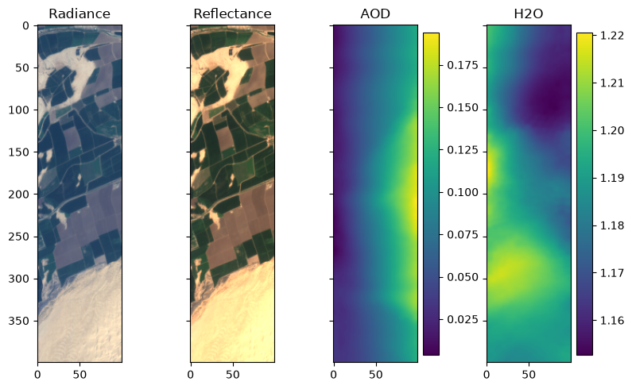